# Network Analysis

## Pengantar Analisis Jaringan

Jaringan (network) adalah kumpulan entitas/node/vertek/simpul yang saling berhubungan, dengan suatu edge, yang dapat berkomunikasi atau bertukar informasi satu sama lain.

Jaringan dapat ditemukan dalam berbagai konteks, termasuk sistem sosial (*social network*), teknologi (*technological network*), dan biologis (*biological network*).

- Dalam **jaringan sosial (social network)**, simpulnya mungkin adalah individu, dan hubungan di antara mereka mungkin mewakili hubungan seperti persahabatan, ikatan keluarga, atau kolaborasi profesional.
- Dalam **jaringan teknologi (technological network)**, node dapat berupa perangkat seperti komputer atau ponsel pintar, dan koneksi di antara keduanya dapat berupa koneksi internet atau seluler.
- Dalam **jaringan biologis (biological network)**, simpulnya bisa berupa sel atau protein, dan hubungan di antara keduanya mungkin mewakili interaksi kimia atau fisik.

Analisis jaringan (network analysis) merupakan metode mempelajari hubungan antar entitas dalam suatu jaringan. Metode ini melibatkan analisis hubungan, atau tautan, antara entitas, serta karakteristik entitas itu sendiri. Analisis jaringan dapat digunakan untuk mempelajari berbagai sistem, termasuk jaringan sosial, jaringan transportasi, dan jaringan biologis.

## Struktur Jaringan

Struktur jaringan ditunjukkan dengan suatu graf. Graf merupakan gambar atau pola dari penghubungan antara himpunan elemen-elemen tidak kosong yang disebut titik (verteks/node/simpul) dengan himpunan pasangan tidak terurut titik-titik tersebut yang disebut sisi (edge).

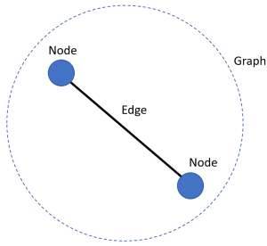

### Tipe Graf

Berbagai variasi dari graf:

- Undirected graphs, tidak memiliki arah hanya sekedar memiliki keterkaitan
- Directed graphs, arah sebagai bagian penting
- Multi graph
- Weighted graphs, edge berisi bobot
- Self-loops, node terhubung ke diri sendiri

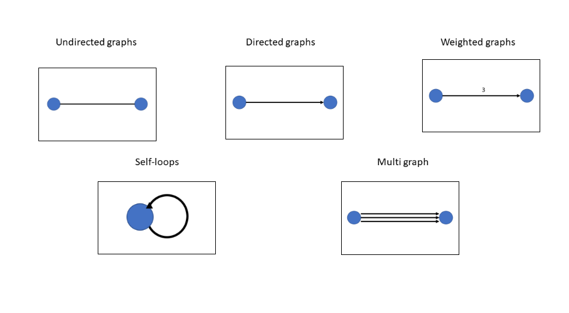

## Visualisasi Jaringan

Pertanyaan kunci dalam merancang visualisasi jaringan adalah:

- Apa tujuan yang ingin diperoleh?
- Properti atau sifat jaringan seperti apa yang ingin disorot?
- Apa permasalahan utama yang ingin ditangani?

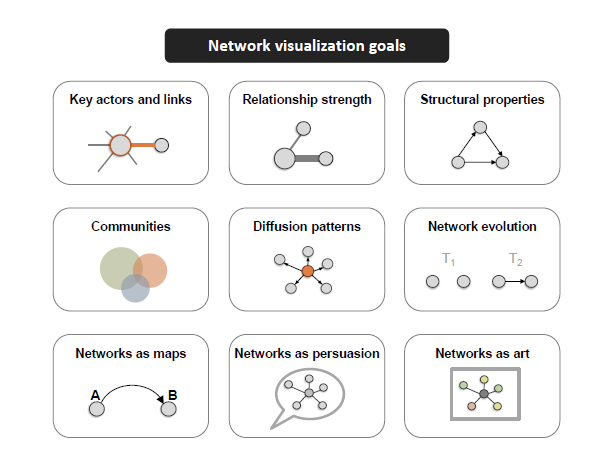

Contoh visualisasi di atas adalah variasi tujuan dalam melihat gambaran suatu jaringan, dalam beberapa kasus bagan sederhana atau bahkan yang lebih kompleks bisa saja lebih sesuai.

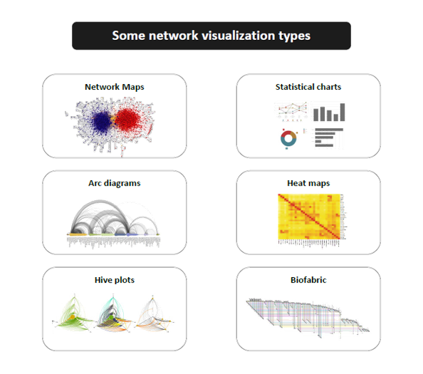

Format lain dalam visualisasi jaringan memiliki beberapa elemen penting sebagai pengatur output yang ingin disajikan. Beberapa yang utama yaitu warna, ukuran, bentuk, dan posisi.

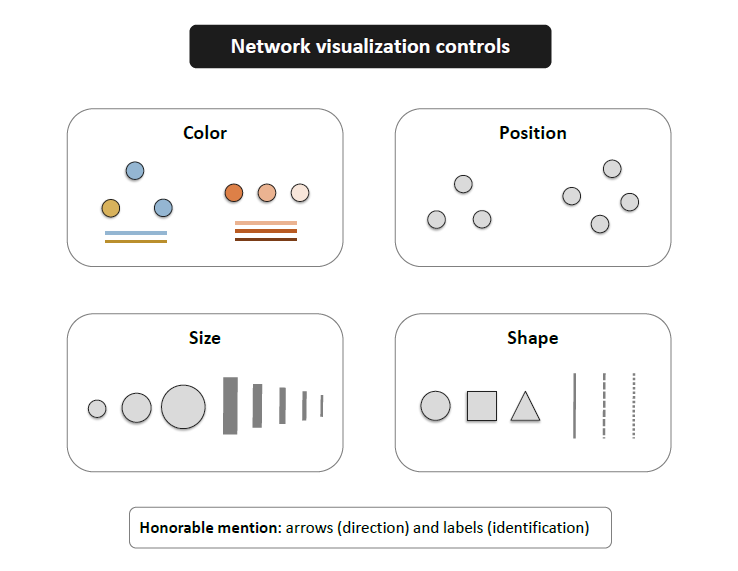

Layout graf modern dapat dioptimalkan dengan kecepatan and estetik, khususnya meminimumkan titik overlaps dan persilangan edge, serta memastikan panjang edge yang serupa yang melalui graf.

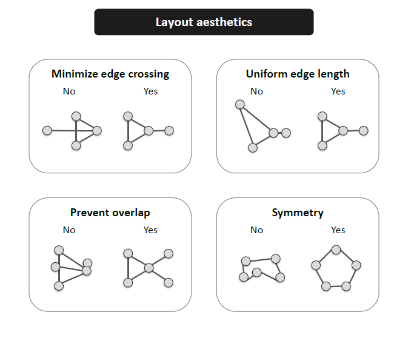

## Analisis Jaringan di R

Package di R yang dapat digunakan untuk melakukan analisis jaringan salah satunya `igraph`

Tujuan utama paket `igraph` adalah untuk menyediakan sekumpulan tidak data dan fungsi untuk:

1. implementasi algoritma graf dengan mudah,
2. penanganan dan pembuatan graf dengan ukuran besar, dengan jutaan node dan edge,
3. memungkinkan pembuatan graf dengan waktu yang efektif melalui bahasa pemgrograman *high-level* seperti R

### Undirected graph

```r
g1 <- graph(edges=c(1,2, 2,3, 3, 1), n=3, directed=F)
g1
```

```
IGRAPH 66fd661 U--- 3 3 --
+ edges from 66fd661:
[1] 1--2 2--3 1--3
```

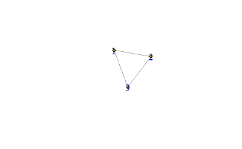

```r
plot(g1)
```

### Directed graph

```r
g2 <- graph(
  edges = c(1,2, 2,3, 3, 1),
  n=10
)
g2
```

```
IGRAPH e532282 D--- 10 3 --
+ edges from e532282:
[1] 1->2 2->3 3->1
```

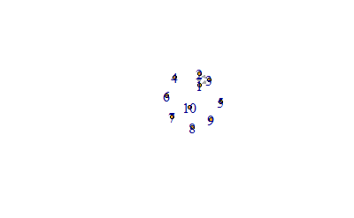

```r
plot(g2)
```

```r
g3 <- graph(
  c("John", "Jim", "Jim", "Jill", "Jill", "John") # nama simpul
)
g3
```

```
IGRAPH 1c73dac DN-- 3 3 --
+ attr: name (v/c)
+ edges from 1c73dac (vertex names):
[1] John->Jim  Jim ->Jill Jill->John
```

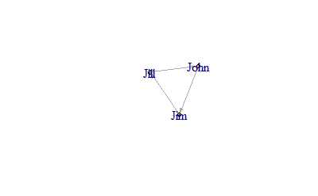

```r
plot(g3)
```

### Matriks

```r
g3[]
```

```
3 x 3 sparse Matrix of class "dgCMatrix"
     John Jim Jill
John    .   1    .
Jim     .   .    1
Jill    1   .    .
```

## Studi Kasus: Jenis Media di USA

Berikut ini ada studi kasus untuk melihat jaringan berbagai jenis media di USA. Dua gugus data berukuran kecil berikut ini berisi organisasi yang bergerak di bidang media. Data pertama berisi media yang terkoneksi dengan sumber media lainnya melalui sebuah jaringan *hyperlink* dan *mention*. Data yang kedua berisi jaringan yang menghubungkan media dengan konsumer media tersebut.

```r
nodes <- read.csv("Dataset1-Media-Example-NODES.csv", header=T, as.is=T)
head(nodes)
```

|  | id | media | media.type | type.label | audience.size |
| --- | --- | --- | --- | --- | --- |
| 1 | s01 | NY Times | 1 | Newspaper | 20 |
| 2 | s02 | Washington Post | 1 | Newspaper | 25 |
| 3 | s03 | Wall Street Journal | 1 | Newspaper | 30 |
| 4 | s04 | USA Today | 1 | Newspaper | 32 |
| 5 | s05 | LA Times | 1 | Newspaper | 20 |
| 6 | s06 | New York Post | 1 | Newspaper | 50 |

```r
nrow(nodes)
```

```
[1] 17
```

```r
length(unique(nodes$id))
```

```
[1] 17
```

```r
links <- read.csv("Dataset1-Media-Example-EDGES.csv", header=T, as.is=T)
head(links)
```

|  | from | to | weight | type |
| --- | --- | --- | --- | --- |
| 1 | s01 | s02 | 10 | hyperlink |
| 2 | s01 | s02 | 12 | hyperlink |
| 3 | s01 | s03 | 22 | hyperlink |
| 4 | s01 | s04 | 21 | hyperlink |
| 5 | s04 | s11 | 22 | mention |
| 6 | s05 | s15 | 21 | mention |

```r
nrow(links)
```

```
[1] 52
```

```r
nrow(unique(links[,c("from", "to")]))
```

```
[1] 49
```

### Penyesuaian edge yang lebih dari satu

Penyesuaian edge yang lebih dari satu dengan cara menjumlahkan hubungannya menjadi suatu bobot

```r
links_weight <- aggregate(links[,3], links[,-3], sum)
links_weight <- links_weight[order(links_weight$from, links_weight$to),]

colnames(links_weight)[4] <- "weight"
rownames(links_weight) <- NULL

head(links_weight)
```

|  | from | to | type | weight |
| --- | --- | --- | --- | --- |
| 1 | s01 | s02 | hyperlink | 22 |
| 2 | s01 | s03 | hyperlink | 22 |
| 3 | s01 | s04 | hyperlink | 21 |
| 4 | s01 | s15 | mention | 20 |
| 5 | s02 | s01 | hyperlink | 23 |
| 6 | s02 | s03 | hyperlink | 21 |

### Eksplorasi graf

Tahapan untuk membuat visualisasi graf dari data frame

```r
net <- graph_from_data_frame(d=links_weight, vertices=nodes, directed=T)
net
```

```
IGRAPH 90aedd3 DNW- 17 49 --
+ attr: name (v/c), media (v/c), media.type (v/n), type.label (v/c), audience.size (v/n), type (e/c),
| weight (e/n)
+ edges from 90aedd3 (vertex names):
 [1] s01->s02 s01->s03 s01->s04 s01->s15 s02->s01 s02->s03 s02->s09 s02->s10 s03->s01 s03->s04 s03->s05 s03->s08
[13] s03->s10 s03->s11 s03->s12 s04->s03 s04->s06 s04->s11 s04->s12 s04->s17 s05->s01 s05->s02 s05->s09 s05->s15
[25] s06->s06 s06->s16 s06->s17 s07->s03 s07->s08 s07->s10 s07->s14 s08->s03 s08->s07 s08->s09 s09->s10 s10->s03
[37] s12->s06 s12->s13 s12->s14 s13->s12 s13->s17 s14->s11 s14->s13 s15->s01 s15->s04 s15->s06 s16->s06 s16->s17
[49] s17->s04
```

```r
E(net) # The edges of the "net" object
```

```
+ 49/49 edges from 90aedd3 (vertex names):
 [1] s01->s02 s01->s03 s01->s04 s01->s15 s02->s01 s02->s03 s02->s09 s02->s10 s03->s01 s03->s04 s03->s05 s03->s08
[13] s03->s10 s03->s11 s03->s12 s04->s03 s04->s06 s04->s11 s04->s12 s04->s17 s05->s01 s05->s02 s05->s09 s05->s15
[25] s06->s06 s06->s16 s06->s17 s07->s03 s07->s08 s07->s10 s07->s14 s08->s03 s08->s07 s08->s09 s09->s10 s10->s03
[37] s12->s06 s12->s13 s12->s14 s13->s12 s13->s17 s14->s11 s14->s13 s15->s01 s15->s04 s15->s06 s16->s06 s16->s17
[49] s17->s04
```

```r
E(net)$type # Edge attribute "type"
```

```
 [1] "hyperlink" "hyperlink" "hyperlink" "mention"   "hyperlink" "hyperlink" "hyperlink" "hyperlink" "hyperlink"
[10] "hyperlink" "hyperlink" "hyperlink" "mention"   "hyperlink" "hyperlink" "hyperlink" "mention"   "mention"
[19] "hyperlink" "mention"   "mention"   "hyperlink" "hyperlink" "mention"   "hyperlink" "hyperlink" "mention"
[28] "mention"   "mention"   "hyperlink" "mention"   "hyperlink" "mention"   "mention"   "mention"   "hyperlink"
[37] "mention"   "hyperlink" "mention"   "hyperlink" "mention"   "mention"   "mention"   "hyperlink" "hyperlink"
[46] "hyperlink" "hyperlink" "mention"   "hyperlink"
```

```r
V(net) # The vertices of the "net" object
```

```
+ 17/17 vertices, named, from 90aedd3:
 [1] s01 s02 s03 s04 s05 s06 s07 s08 s09 s10 s11 s12 s13 s14 s15 s16 s17
```

```r
V(net)$media # Vertex attribute "media"
```

```
 [1] "NY Times"            "Washington Post"     "Wall Street Journal" "USA Today"           "LA Times"
 [6] "New York Post"       "CNN"                 "MSNBC"               "FOX News"            "ABC"
[11] "BBC"                 "Yahoo News"          "Google News"         "Reuters.com"         "NYTimes.com"
[16] "WashingtonPost.com"  "AOL.com"
```

```r
# Find nodes by attribute:
# (that returns oblects of type vertex sequence)
V(net)[media=="BBC"]
```

[output not shown]

```r
# Find edges by attribute:
# (that returns oblects of type edge sequence)
E(net)[type=="mention"]
```

[output not shown]

```r
# You can also examine the network matrix directly:
net[1,]
```

```
s01 s02 s03 s04 s05 s06 s07 s08 s09 s10 s11 s12 s13 s14 s15 s16 s17
  0  22  22  21   0   0   0   0   0   0   0   0   0   0  20   0   0
```

```r
net[5,7]
```

```
[1] 0
```

```r
# Get an edge list or a matrix:
as_edgelist(net, names=T)
```

[output not shown]

[output cut: 38 more lines]

```r
as_adjacency_matrix(net, attr="weight")
```

```
17 x 17 sparse Matrix of class "dgCMatrix"
```

```
   [[ suppressing 17 column names ‘s01’, ‘s02’, ‘s03’ ... ]]
```

```
s01  . 22 22 21 .  .  .  .  .  .  .  .  .  . 20  .  .
s02 23  . 21  . .  .  .  .  1  5  .  .  .  .  .  .  .
s03 21  .  . 22 1  .  .  4  .  2  1  1  .  .  .  .  .
s04  .  . 23  . .  1  .  .  .  . 22  3  .  .  .  .  2
s05  1 21  .  . .  .  .  .  2  .  .  .  .  . 21  .  .
s06  .  .  .  . .  1  .  .  .  .  .  .  .  .  . 21 21
s07  .  .  1  . .  .  . 22  . 21  .  .  .  4  .  .  .
s08  .  .  2  . .  . 21  . 23  .  .  .  .  .  .  .  .
s09  .  .  .  . .  .  .  .  . 21  .  .  .  .  .  .  .
s10  .  .  2  . .  .  .  .  .  .  .  .  .  .  .  .  .
s11  .  .  .  . .  .  .  .  .  .  .  .  .  .  .  .  .
s12  .  .  .  . .  2  .  .  .  .  .  . 22 22  .  .  .
s13  .  .  .  . .  .  .  .  .  .  . 21  .  .  .  .  1
s14  .  .  .  . .  .  .  .  .  .  1  . 21  .  .  .  .
s15 22  .  .  1 .  4  .  .  .  .  .  .  .  .  .  .  .
s16  .  .  .  . . 23  .  .  .  .  .  .  .  .  .  . 21
s17  .  .  .  4 .  .  .  .  .  .  .  .  .  .  .  .  .
```

```r
# Or data frames describing nodes and edges:
as_data_frame(net, what="edges")
```

[output not shown]

[output cut: 42 more lines]

```r
as_data_frame(net, what="vertices")
```

|  | name | media | media.type | type.label | audience.size |
| --- | --- | --- | --- | --- | --- |
| s01 | s01 | NY Times | 1 | Newspaper | 20 |
| s02 | s02 | Washington Post | 1 | Newspaper | 25 |
| s03 | s03 | Wall Street Journal | 1 | Newspaper | 30 |
| s04 | s04 | USA Today | 1 | Newspaper | 32 |
| s05 | s05 | LA Times | 1 | Newspaper | 20 |
| s06 | s06 | New York Post | 1 | Newspaper | 50 |
| s07 | s07 | CNN | 2 | TV | 56 |
| s08 | s08 | MSNBC | 2 | TV | 34 |
| s09 | s09 | FOX News | 2 | TV | 60 |
| s10 | s10 | ABC | 2 | TV | 23 |

[output cut: 7 more lines]

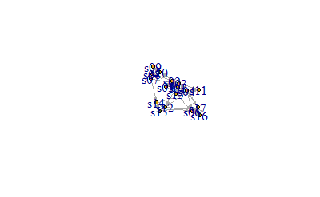

```r
plot(net)
```

Graf tersebut tidak cukup mudah untuk diinterpretasi, sehingga perlu dilakukan beberapa pengaturan:

- menghilangkan loops
- menghilangkan label

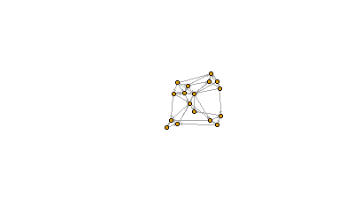

```r
net <- simplify(net, remove.multiple = F, remove.loops = T)
plot(net, edge.arrow.size=.4,vertex.label=NA)
```

Pelabelan bedasarkan nama node

[figure not shown]

```r
plot(net, edge.arrow.size=.2, edge.color="orange",
vertex.color="orange", vertex.frame.color="#ffffff",
vertex.label=V(net)$media, vertex.label.color="black")
```

Melakukan beberapa pengaturan dalam membuat visualisasi network

[figure not shown]

```r
# Generate colors based on media type:
colrs <- c("gray50", "tomato", "gold")
V(net)$color <- colrs[V(net)$media.type]
# Compute node degrees (#links) and use that to set node size:
deg <- degree(net, mode="all")
V(net)$size <- deg*3
# We could also use the audience size value:
V(net)$size <- V(net)$audience.size*0.6
# The labels are currently node IDs.
# Setting them to NA will render no labels:
V(net)$label <- NA
# Set edge width based on weight:
E(net)$width <- E(net)$weight/6
#change arrow size and edge color:
E(net)$arrow.size <- .2
E(net)$edge.color <- "gray80"
E(net)$width <- 1+E(net)$weight/12
plot(net)
legend(x=-1.5, y=-1.1, c("Newspaper","Television", "Online News"), pch=21,
col="#777777", pt.bg=colrs, pt.cex=2, cex=.8, bty="n", ncol=1)
```

Beberapa layout yang disediakan pada paket `igraph`

```
[1] "layout_as_star"
[1] "layout_components"
[1] "layout_in_circle"
[1] "layout_nicely"
[1] "layout_on_grid"
[1] "layout_on_sphere"
[1] "layout_randomly"
[1] "layout_with_dh"
[1] "layout_with_drl"
[1] "layout_with_fr"
```

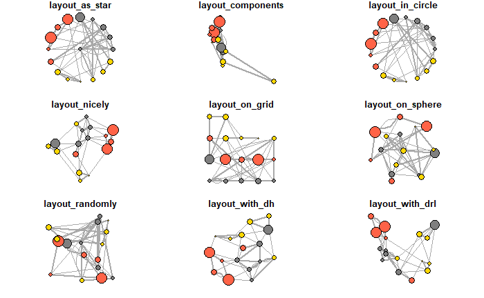

```
[1] "layout_with_gem"
[1] "layout_with_graphopt"
[1] "layout_with_kk"
[1] "layout_with_lgl"
[1] "layout_with_mds"
```

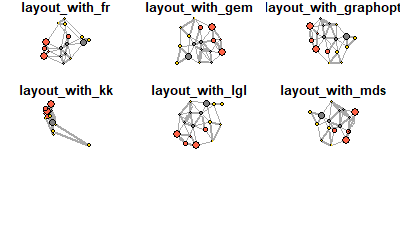

```r
layouts <- grep("^layout_", ls("package:igraph"), value=TRUE)[-1]
# Remove layouts that do not apply to our graph.
layouts <- layouts[!grepl("bipartite|merge|norm|sugiyama|tree", layouts)]


par(mfrow=c(3,3), mar=c(1,1,1,1))
for (layout in layouts) {
  print(layout)
  l <- do.call(layout, list(net))
  plot(net, edge.arrow.mode=0, layout=l, main=layout)
}
```

## Visualisasi Interaktif dengan `visNetwork`

Salah satu package di R yang dapat digunakan untuk membuat visualisasi secara interaktif ialah package `visNetwork`

```r
install.packages('visNetwork')
```

```r
visNetwork(
  nodes = NULL,
  edges = NULL,
  dot = NULL,
  gephi = NULL,
  width = NULL,
  height = NULL,
  main = NULL,
  submain = NULL,
  footer = NULL,
  background = "rgba(0, 0, 0, 0)",
  ...
)
```

```r
nod <- data.frame(
  id = nodes$id,
  label = nodes$media,
  group = nodes$media.type,
  shape = "circle",
  title = nodes$media,
  color = nodes$media.type,
  shadow = TRUE
)
head(nod)
```

|  | id | label | group | shape | title | color | shadow |
| --- | --- | --- | --- | --- | --- | --- | --- |
| 1 | s01 | NY Times | 1 | circle | NY Times | 1 | TRUE |
| 2 | s02 | Washington Post | 1 | circle | Washington Post | 1 | TRUE |
| 3 | s03 | Wall Street Journal | 1 | circle | Wall Street Journal | 1 | TRUE |
| 4 | s04 | USA Today | 1 | circle | USA Today | 1 | TRUE |
| 5 | s05 | LA Times | 1 | circle | LA Times | 1 | TRUE |
| 6 | s06 | New York Post | 1 | circle | New York Post | 1 | TRUE |

```r
edg <- data.frame(
  from = links$from,
  to = links$to,
  label = paste("Edge", 1:length(links$from)), # labels
  length = 100,
  arrows = "to",
  dashes = TRUE,
  title = paste("Edge", 1:length(links$from)),
  smooth = TRUE, # smooth
  shadow = TRUE
)
head(edg)
```

|  | from | to | label | length | arrows | dashes | title | smooth | shadow |
| --- | --- | --- | --- | --- | --- | --- | --- | --- | --- |
| 1 | s01 | s02 | Edge 1 | 100 | to | TRUE | Edge 1 | TRUE | TRUE |
| 2 | s01 | s02 | Edge 2 | 100 | to | TRUE | Edge 2 | TRUE | TRUE |
| 3 | s01 | s03 | Edge 3 | 100 | to | TRUE | Edge 3 | TRUE | TRUE |
| 4 | s01 | s04 | Edge 4 | 100 | to | TRUE | Edge 4 | TRUE | TRUE |
| 5 | s04 | s11 | Edge 5 | 100 | to | TRUE | Edge 5 | TRUE | TRUE |
| 6 | s05 | s15 | Edge 6 | 100 | to | TRUE | Edge 6 | TRUE | TRUE |

```r
visNetwork(nod, edg)
```

[interactive chart not shown]

```r
visNetwork(nod, edg) %>%
  visOptions(highlightNearest = TRUE, selectedBy = "label")
```

[interactive chart not shown]